# Module 6 PSET

## [ 5.4 ]

#### [ Problem 4 ]

```
The article “Hatching Distribution of Eggs Varying in Weight and Breeder Age” (S. Viera, J. Almeida, et al., Brazilian Journal of Poultry Science 2005: 73–78) presents the results of a study in which the weights of 296 eggs from 27 week-old breeding hens averaged 54.1g with a standard deviation of 4.4g, and weights of 296 eggs from 59 week-old hens av- eraged 72.7 g with a standard deviation of 4.7 g. Find a 95% confidence interval for the difference between the mean weights.
```

Given:

- $n_X = n_Y = 296$ (since both sample sizes are equal)
- $\bar{X} = \mu_{27w} = 54.1$ grams (mean weight of eggs from 27 week-old hens)
- $\bar{Y} = \mu_{59w} = 72.7$ grams (mean weight of eggs from 59 week-old hens)
- $s_X = 4.4$ grams (standard deviation for 27 week-old hens)
- $s_Y = 4.7$ grams (standard deviation for 59 week-old hens)

```
norm.ppf(1-0.05/2) = 1.96 # z score or alpha/2
```

$$ (\bar{Y} - \bar{X}) \pm z_{\alpha/2} \times \sqrt{\frac{s_X^2}{n_X} + \frac{s_Y^2}{n_Y}} $$ $$ (72.7 - 54.1) \pm 1.96 \times \sqrt{\frac{4.4^2}{296} + \frac{4.7^2}{296}} $$ $$ 18.6 \pm 1.96 \times 0.3743 $$ $$ 18.6 \pm 0.7336 $$

Therefore, the 95% confidence interval for the difference between the mean weights is:

$$ (17.8664, 19.3336) \text{ grams} $$

This means we can be 95% confident that the true difference in mean weights between the eggs from 27 week-old and 59 week-old breeding hens lies within this interval.

```python
import math
from scipy.stats import norm

math.sqrt(4.4**2/296 + 4.7**2 /296)
1.96 * 0.3743
norm.ppf(0.975)
```

```
1.959963984540054
```

## [6.5]

### Problem 2

```
The article “Some Parameters of the Population
Biology of Spotted Flounder (Ciutharus linguatula
Linnaeus, 1758) in Edremit Bay (North Aegean Sea)”
(D. T¨urker, B. Bayhan, et al., Turkish Journal of Veteri-
nary and Animal Science, 2005:1013–1018) reports
that a sample of 482 female spotted ﬂounder had an
average weight of 20.95 g with a standard deviation of
14.5 g, and a sample of 614 male spotted ﬂounder had
an average weight of 22.79 g with a standard deviation
of 15.6 g. Can you conclude that the mean weight of
male spotted ﬂounder is greater than that of females?
```

Given:

- Female spotted flounder sample:
  - Size ($n_f = 482$)
  - Mean weight ($\bar{x}_f = 20.95$ g)
  - Standard deviation ($s_f = 14.5$ g)
- Male spotted flounder sample:
  - Size ($n_m = 614$)
  - Mean weight ($\bar{x}_m = 22.79$ g)
  - Standard deviation ($s_m = 15.6$ g)

find t statistic:

$$ t = \frac{\bar{x}_m - \bar{x}_f}{\sqrt{\frac{s_m^2}{n_m} + \frac{s_f^2}{n_f}}} $$

$$ t = \frac{22.79 - 20.95}{\sqrt{\frac{15.6^2}{614} + \frac{14.5^2}{482}}} $$

$$ t = \frac{1.84}{\sqrt{0.8327}} = \frac{1.84}{0.9120} \approx 2.017 $$

$$ \text{degrees\_of\_freedom }= 614 + 482 -2 = 1094 $$

```
stats.t.sf(2.017, 1094) = 0.0219 = 2.19%
```

therefore, because the p-value is less than the chosen significance level of 5%, we reject the null hypothesis, concluding there is a significant difference in mean weights with male flounders being heavier.

```python
from scipy.stats import t
print(t.sf(2.017, 22))
print(614 + 482 -2)
t.sf(2.017, 1094)
```

```
0.028030541450905853
1094
```

```
0.02196970798946862
```

## [5.7]

### Problem 2

```
. The article “Effect of Refrigeration on the Potassium
Bitartrate Stability and Composition of Italian Wines”
(A. Versari, D. Barbanti, et al., Italian Journal of Food
Science, 2002:45–52) reports a study in which eight
types of white wine had their tartaric acid concentra-
tion (in g/L) measured both before and after a cold
stabilization process. The results are presented in the
following table
```

Given differences:

- Differences in tartaric acid concentration: $0.27, 0.38, 0.26, 0.04, 0.02, 0.23, 0.16, 0.19$

$$ \bar{x}_d = \frac{\sum_{i=1}^{n} x_i}{n} $$

$$ s_d = \sqrt{\frac{\sum_{i=1}^{n} (x_i - \bar{x}_d)^2}{n - 1}} $$

$$ \bar{x}_d = \frac{0.27 + 0.38 + 0.26 + 0.04 + 0.02 + 0.23 + 0.16 + 0.19}{8} $$

$$ \bar{x}_d = \frac{1.55}{8} = 0.19375 \text{ g/L} $$

Calculate $s_d$ using the sample mean difference:

$$ s_d = \sqrt{\frac{(0.27-0.19375)^2 + (0.38-0.19375)^2 + (0.26-0.19375)^2 + (0.04-0.19375)^2 + (0.02-0.19375)^2 + (0.23-0.19375)^2 + (0.16-0.19375)^2 + (0.19-0.19375)^2}{7}} $$

The 95% confidence interval for the mean difference can be calculated using the t-distribution (since the sample size is small):

$$ \text{CI} = \bar{x}_d \pm t^* \frac{s_d}{\sqrt{n}} $$

$$ \text{ME} = t^* \frac{s_d}{\sqrt{8}} $$

```python
import math

data = [0.27, 0.38, 0.26, 0.04, 0.02, 0.23, 0.16, 0.19]
mean = sum(data) / len(data)

# Calculating the variance
variance = sum((x - mean) ** 2 for x in data) / (len(data) - 1)

# Standard deviation is the square root of variance
std_deviation = math.sqrt(variance)

print("Mean:", mean)
print("Standard Deviation:", std_deviation)
```

```
Mean: 0.19375
Standard Deviation: 0.12023043351355406
```

## [6.8]

### Problem 6

### Given Data:

- Processor A times: 27.2, 18.1, 27.2, 19.7, 24.5, 22.1
- Processor B times: 24.1, 19.3, 26.8, 20.1, 27.6, 29.8
- Differences (Processor A - Processor B): $3.1, -1.2, 0.4, -0.4, -3.1, -7.7$

$$ \bar{d} = \frac{\sum_{i=1}^6 d_i}{6} $$

$$ s_d = \sqrt{\frac{\sum_{i=1}^6 (d_i - \bar{d})^2}{5}} $$

Substitute the differences to compute $\bar{d}$: $$ \bar{d} = \frac{3.1 - 1.2 + 0.4 - 0.4 - 3.1 - 7.7}{6} $$

Calculate $s_d$ using the sample mean difference: $$ s_d = \sqrt{\frac{(3.1 - \bar{d})^2 + (-1.2 - \bar{d})^2 + (0.4 - \bar{d})^2 + (-0.4 - \bar{d})^2 + (-3.1 - \bar{d})^2 + (-7.7 - \bar{d})^2}{5}} $$

## [7.1]

### Problem 4

```
4. True or false, and explain brieﬂy:
a. If the correlation coefﬁcient is positive, then
above-average values of one variable are asso-
ciated with above-average values of the other.
b. If the correlation coefﬁcient is negative, then
below-average values of one variable are asso-
ciated with below-average values of the other.
c. If y is usually less than x, then the correlation
between y and x will be negative
```

**Answer and Explanation:**

a. **True.** If the correlation coefficient is positive, then there is a positive linear relationship between the two variables.

b. **False.** If the correlation coefficient is negative, this indicates a negative linear relationship between the two variables, meaning that as one variable increases, the other tends to decrease.

c. **False.** If (y) is usually less than (x), this alone does not necessarily imply that the correlation between (y) and (x) will be negative. The correlation measures the strength and direction of a linear relationship between two variables. If (y) consistently increases as (x) increases, but at a lower rate (i.e., (y) is always less than (x)), the correlation could still be positive. The correlation being negative would require that (y) decreases as (x) increases, or vice versa.

### Problem 6

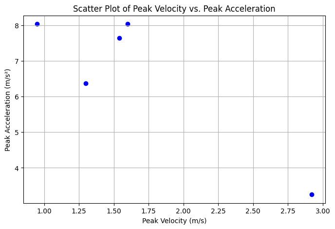

```
correlation coefficient = -0.8843573162549511
```

```python
import numpy as np
import matplotlib.pyplot as plt

# Data for the velocities and accelerations
velocities = np.array([1.54, 1.60, 0.95, 1.30, 2.92])
accelerations = np.array([7.64, 8.04, 8.04, 6.37, 3.25])

# a. Compute the correlation coefficient
correlation_coefficient = np.corrcoef(velocities, accelerations)[0, 1]

# b. Construct a scatterplot
plt.figure(figsize=(8, 5))
plt.scatter(velocities, accelerations, color='blue')
plt.title('Scatter Plot of Peak Velocity vs. Peak Acceleration')
plt.xlabel('Peak Velocity (m/s)')
plt.ylabel('Peak Acceleration (m/s²)')
plt.grid(True)
plt.show()

print(f"correlation coefficient = {correlation_coefficient}")
```

d. **Effect of Unit Conversion:** Changing the units from meters to centimeters for velocity and acceleration, and from seconds to minutes for time, does not affect the correlation coefficient. Correlation coefficients are unitless measures of the strength and direction of a linear relationship between two variables. Changing units uniformly across all data points only scales the data but does not alter the nature of their relationship. Therefore, the correlation coefficient remains the same regardless of the units used.

### Problem 10

a. **P-value and Hypothesis Testing:** With a correlation coefficient $r = 0.15$ and a sample size of $n = 300$, we can use the t-distribution to test the null hypothesis $H_0: \rho \leq 0$ against the alternative $H_1: \rho > 0$. The test statistic $t$ can be calculated using the formula:

$$ t = \frac{r \sqrt{n-2}}{\sqrt{1-r^2}} $$

Substituting the given values:

$$ t = \frac{0.15 \sqrt{298}}{\sqrt{1-0.15^2}} \approx \frac{0.15 \cdot 17.2627}{0.9889} \approx 2.619 $$

For $n-2 = 298$ degrees of freedom, we look up or calculate the P-value corresponding to $t = 2.619$ on a t-distribution. This value indicates the probability of observing a correlation as extreme as 0.15 or more under the null hypothesis. Typically, if the P-value is less than 0.05, we reject $H_0$ and conclude $\rho > 0$. Given the moderate value of $t$ and a large sample size, it is likely that the P-value is less than 0.05, suggesting that $\rho > 0$.

b. **Correlation Between Eccentricity and Smoothness:** The result in part (a) does not allow us to conclude that there is a strong correlation between eccentricity and smoothness. The question about the correlation between diameter and length (r = 0.15) suggests only a weak positive linear relationship. This result does not imply any conclusions about the correlation between eccentricity and smoothness, as these are different measurements not discussed in the correlation between diameter and length. Additionally, a correlation of 0.15, while statistically significant, is not indicative of a strong correlation.

## [ 7.2 ]

### Problem 2

a. **Predicting Tensile Strength:** The least-squares regression line given is $y = -196.32 + 2.42x$, where $y$ is the tensile strength in ksi and $x$ is the Brinell hardness. To predict the tensile strength of a specimen with a Brinell hardness of 102.7, substitute $x = 102.7$ into the equation:

$$ y = -196.32 + 2.42 \times 102.7 $$

$$ y = -196.32 + 248.534 $$

$$ y = 52.214 \text{ ksi} $$

Thus, the predicted tensile strength of a specimen with a Brinell hardness of 102.7 is approximately 52.214 ksi.

b. **Difference in Tensile Strengths Due to Hardness Difference:** The question asks by how much the tensile strengths are predicted to differ if two specimens differ in their Brinell hardness by 3 units. Using the slope of the least-squares line, which is $2.42$, the difference in tensile strength, $\Delta y$, for a $\Delta x$ change in Brinell hardness can be calculated as:

$$ \Delta y = 2.42 \times \Delta x $$

$$ \Delta y = 2.42 \times 3 = 7.26 \text{ ksi} $$

Therefore, if two specimens differ in their Brinell hardness by 3 units, their tensile strengths are predicted to differ by 7.26 ksi.

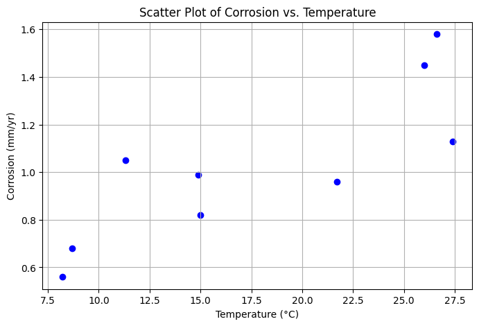

```
{'slope': 0.035509163477910624,
 'intercept': 0.3939595195810982,
 'predicted_difference': 0.3550916347791062,
 'predicted_corrosion_20C': 1.1041427891393107,
 'fitted_values': array([1.33850327, 1.31719777, 1.3669106 , 1.16450837, 0.92304606,
       0.79521307, 0.92659697, 0.70288924, 0.68513466]),
 'residuals': array([ 0.24149673,  0.13280223, -0.2369106 , -0.20450837,  0.06695394,
        0.25478693, -0.10659697, -0.02288924, -0.12513466]),
 'largest_residual_temperature': 11.3,
 'largest_residual_value': 0.25478693311851175}
```

```python
! bass source sklearn-env/bin/activate
import numpy as np
import matplotlib.pyplot as plt
from sklearn.linear_model import LinearRegression

# Data from the study
temperature = np.array([26.6, 26.0, 27.4, 21.7, 14.9, 11.3, 15.0, 8.7, 8.2])
corrosion = np.array([1.58, 1.45, 1.13, 0.96, 0.99, 1.05, 0.82, 0.68, 0.56])

# a. Construct a scatterplot
plt.figure(figsize=(8, 5))
plt.scatter(temperature, corrosion, color='blue')
plt.title('Scatter Plot of Corrosion vs. Temperature')
plt.xlabel('Temperature (°C)')
plt.ylabel('Corrosion (mm/yr)')
plt.grid(True)
plt.show()

# b. Compute the least-squares line
model = LinearRegression()
model.fit(temperature.reshape(-1, 1), corrosion.reshape(-1, 1))
slope = model.coef_[0][0]
intercept = model.intercept_[0]

# c. Predict difference in corrosion for 10°C difference
predicted_difference = slope * 10

# d. Predict corrosion at 20°C
predicted_corrosion_20C = model.predict([[20]])[0][0]

# e. Compute the fitted values
fitted_values = model.predict(temperature.reshape(-1, 1)).flatten()

# f. Compute the residuals and find the largest
residuals = corrosion - fitted_values
largest_residual_index = np.argmax(np.abs(residuals))
largest_residual_value = residuals[largest_residual_index]
largest_residual_temperature = temperature[largest_residual_index]

regression_results = {
    "slope": slope,
    "intercept": intercept,
    "predicted_difference": predicted_difference,
    "predicted_corrosion_20C": predicted_corrosion_20C,
    "fitted_values": fitted_values,
    "residuals": residuals,
    "largest_residual_temperature": largest_residual_temperature,
    "largest_residual_value": largest_residual_value
}

from pprint import pp
pp(regression_results)
```

### Answers:

a. **Scatterplot:** The scatterplot displayed shows corrosion vs. temperature. The data do not appear to strictly follow a linear trend, especially at lower temperatures where the rate of corrosion appears to decrease more steeply.

b. **Least-Squares Line:** The fitted least-squares regression line for predicting corrosion from temperature is: $$ y = 0.0355x + 0.394 $$ where $y$ is the corrosion rate and $x$ is the temperature.

c. **Difference in Corrosion for 10°C Difference:** With a slope of approximately 0.0355, a 10°C difference in temperature is predicted to result in a difference in corrosion rates of about 0.3551 mm/yr.

d. **Predicted Corrosion at 20°C:** The predicted corrosion rate for steel submerged in seawater at a temperature of 20°C is approximately 1.104 mm/yr.

e. **Fitted Values:** The fitted values for the given data points are approximately [1.339, 1.317, 1.367, 1.165, 0.923, 0.795, 0.927, 0.703, 0.685].

f. **Residuals and Largest Residual:** The residuals (observed minus fitted values) are approximately [0.242, 0.133, -0.237, -0.205, 0.067, 0.255, -0.107, -0.023, -0.125]. The largest residual is about 0.255 mm/yr at a temperature of 11.3°C.

The scatterplot and the analysis suggest that while there is a general trend of corrosion increasing with temperature, the relationship might not be perfectly linear, particularly at lower temperature ranges.

[output not shown]

## [7.2]

### Problem 12

1. Slope ($b$) of the regression line: $$ b = r \frac{s_y}{s_x} $$
2. Intercept ($a$) of the regression line: $$ a = \bar{y} - b\bar{x} $$

Given the following values:

- Correlation coefficient ($r$) = 0.7
- Standard deviation of curing times ($s_x$) = 2 days
- Standard deviation of compressive strengths ($s_y$) = 100 MPa
- Mean of curing times ($\bar{x}$) = 5 days
- Mean of compressive strengths ($\bar{y}$) = 1350 MPa

Substitute the given values into the slope formula: $$ b = 0.7 \frac{100}{2} = 35 \text{ MPa/day} $$

Next, calculate the intercept: $$ a = 1350 - 35 \times 5 = 1175 \text{ MPa} $$

Thus, the equation of the least-squares line is: $$ y = 35x + 1175 $$

This equation can be used to predict the compressive strength ($y$) in MPa of concrete specimens based on their curing time ($x$) in days.

## [7.4]

### Problem 12

1. Slope ($b$) of the regression line: $$ b = r \frac{s_y}{s_x} $$
2. Intercept ($a$) of the regression line: $$ a = \bar{y} - b\bar{x} $$

Given the following values:

- Correlation coefficient ($r$) = 0.7
- Standard deviation of curing times ($s_x$) = 2 days
- Standard deviation of compressive strengths ($s_y$) = 100 MPa
- Mean of curing times ($\bar{x}$) = 5 days
- Mean of compressive strengths ($\bar{y}$) = 1350 MPa

Substitute the given values into the slope formula: $$ b = 0.7 \frac{100}{2} = 35 \text{ MPa/day} $$

Next, calculate the intercept: $$ a = 1350 - 35 \times 5 = 1175 \text{ MPa} $$

Thus, the equation of the least-squares line is: $$ y = 35x + 1175 $$

This equation can be used to predict the compressive strength ($y$) in MPa of concrete specimens based on their curing time ($x$) in days.